# SimpleITK Image Basics

This document will give a brief orientation to the SimpleITK Image class.

First we import the SimpleITK Python module. By convention our module is imported into the shorter and more Pythonic "sitk" local name.

```python
%matplotlib inline
import matplotlib.pyplot as plt
import SimpleITK as sitk
```

## Image Construction

There are a variety of ways to create an image. All images' initial value is well defined as zero.

```python
image = sitk.Image(256, 128, 64, sitk.sitkInt16)
image_2D = sitk.Image(64, 64, sitk.sitkFloat32)
image_2D = sitk.Image([32, 32], sitk.sitkUInt32)
image_RGB = sitk.Image([128, 128], sitk.sitkVectorUInt8, 3)
```

### Pixel Types

The pixel type is represented as an enumerated type. The following is a table of the enumerated list.

| sitkUInt8 | Unsigned 8 bit integer |
| --- | --- |
| sitkInt8 | Signed 8 bit integer |
| sitkUInt16 | Unsigned 16 bit integer |
| sitkInt16 | Signed 16 bit integer |
| sitkUInt32 | Unsigned 32 bit integer |
| sitkInt32 | Signed 32 bit integer |
| sitkUInt64 | Unsigned 64 bit integer |
| sitkInt64 | Signed 64 bit integer |
| sitkFloat32 | 32 bit float |
| sitkFloat64 | 64 bit float |
| sitkComplexFloat32 | complex number of 32 bit float |
| sitkComplexFloat64 | complex number of 64 bit float |
| sitkVectorUInt8 | Multi-component of unsigned 8 bit integer |
| sitkVectorInt8 | Multi-component of signed 8 bit integer |
| sitkVectorUInt16 | Multi-component of unsigned 16 bit integer |
| sitkVectorInt16 | Multi-component of signed 16 bit integer |
| sitkVectorUInt32 | Multi-component of unsigned 32 bit integer |
| sitkVectorInt32 | Multi-component of signed 32 bit integer |
| sitkVectorUInt64 | Multi-component of unsigned 64 bit integer |
| sitkVectorInt64 | Multi-component of signed 64 bit integer |
| sitkVectorFloat32 | Multi-component of 32 bit float |
| sitkVectorFloat64 | Multi-component of 64 bit float |
| sitkLabelUInt8 | RLE label of unsigned 8 bit integers |
| sitkLabelUInt16 | RLE label of unsigned 16 bit integers |
| sitkLabelUInt32 | RLE label of unsigned 32 bit integers |
| sitkLabelUInt64 | RLE label of unsigned 64 bit integers |

There is also `sitkUnknown`, which is used for undefined or erroneous pixel ID's. It has a value of -1.

The 64-bit integer types are not available on all distributions. When not available the value is `sitkUnknown`.

### More Information about the Image class be obtained in the Docstring

SimpleITK classes and functions have the Docstrings derived from the C++ definitions and the Doxygen documentation.

```python
help(image)
```

```
Help on Image in module SimpleITK.SimpleITK object:

class Image(builtins.object)
 |  Image(*args)
 |  The Image class for SimpleITK.
 |  This Image class can represent 2D, 3D, and 4D images. The pixel types may be a
 |  scalar, a multi-component vector or a run-length-encoded (RLE)
 |  "label". The dimension, pixel type and size is specified at
 |  construction.
 |  A fundamental concept of ITK images is that they occupy physical space
 |  where the image is defined by an origin, spacing, and direction cosine
 |  matrix. The attributes are taken into consideration when doing most
 |  operations on an image. A meta-data dictionary is also associated with
 |  the image, which may contain additional fields from reading but these
 |  attributes are not propagated by image filters.
 |  The SimpleITK Image provides a single facade interface to several ITK image types.
 |  Internally, the SimpleITK Image maintains a pointer to the ITK image class, and performs reference
 |  counting and lazy copying. This means that deep copying of an image
 |  including it's buffer is delayed until the image is modified. This
 |  removes the need to use pointers to SimpleITK Image class, as copying and returning by value do not unnecessarily
 |  duplicate the data.
 |  See:
 |   itk::Image itk::VectorImage itk::LabelMap itk::ImageBase
 |  C++ includes: sitkImage.h
 |  Methods defined here:
 |  CopyInformation(self, srcImage)
 |      CopyInformation(Image self, Image srcImage)
 |      Copy common meta-data from an image to this one.
 |      Copies the Origin, Spacing, and Direction from the source image to
 |      this image. The meta-data dictionary is not copied.
 |      It is required for the source Image's dimension and size to match, this image's attributes, otherwise an
 |      exception will be generated.
 |  EraseMetaData(self, key)
 |      EraseMetaData(Image self, std::string const & key) -> bool
 |      Remove an entry from the meta-data dictionary.
 |      Returns true, when the value exists in the dictionary and is removed,
 |      false otherwise.
 |  EvaluateAtContinuousIndex(self, index, interp=2)
 |      Interpolate pixel value at a continuous index.
 |      This method is not supported for Label pixel types.
```

[output cut: 439 more lines]

```
 |  __swig_destroy__ = delete_Image(...)
 |      delete_Image(Image self)
 |  ----------------------------------------------------------------------
 |  Data descriptors defined here:
 |  __dict__
 |      dictionary for instance variables
 |  __weakref__
 |      list of weak references to the object
 |  thisown
 |      The membership flag
 |  ----------------------------------------------------------------------
 |  Data and other attributes defined here:
 |  DefaultImageCoordinateTolerance = 1e-06
 |  DefaultImageDirectionTolerance = 1e-06
 |  __hash__ = None
```

## Accessing Attributes

If you are familiar with ITK, then these methods will follow your expectations:

```python
print(image.GetSize())
print(image.GetOrigin())
print(image.GetSpacing())
print(image.GetDirection())
print(image.GetNumberOfComponentsPerPixel())
```

```
(256, 128, 64)
(0.0, 0.0, 0.0)
(1.0, 1.0, 1.0)
(1.0, 0.0, 0.0, 0.0, 1.0, 0.0, 0.0, 0.0, 1.0)
1
```

Note: The starting index of a SimpleITK Image is always 0. If the output of an ITK filter has non-zero starting index, then the index will be set to 0, and the origin adjusted accordingly.

The size of the image's dimensions have explicit accessors:

```python
print(image.GetWidth())
print(image.GetHeight())
print(image.GetDepth())
```

```
256
128
64
```

Since the dimension and pixel type of a SimpleITK image is determined at run-time accessors are needed.

```python
print(image.GetDimension())
print(image.GetPixelIDValue())
print(image.GetPixelIDTypeAsString())
```

```
3
2
16-bit signed integer
```

What is the depth of a 2D image?

```python
print(image_2D.GetSize())
print(image_2D.GetDepth())
```

```
(32, 32)
0
```

What is the dimension and size of a Vector image?

```python
print(image_RGB.GetDimension())
print(image_RGB.GetSize())
```

```
2
(128, 128)
```

```python
print(image_RGB.GetNumberOfComponentsPerPixel())
```

```
3
```

For certain file types such as DICOM, additional information about the image is contained in the meta-data dictionary.

```python
for key in image.GetMetaDataKeys():
    print(f'"{key}":"{image.GetMetaData(key)}"')
```

## Accessing Pixels

There are the member functions `GetPixel` and `SetPixel` which provides an ITK-like interface for pixel access.

```python
help(image.GetPixel)
```

```
Help on method GetPixel in module SimpleITK.SimpleITK:

GetPixel(*idx) method of SimpleITK.SimpleITK.Image instance
    Returns the value of a pixel.

    This method takes 2 parameters in 2D: the x and y index,
    and 3 parameters in 3D: the x, y and z index.
```

```python
print(image.GetPixel(0, 0, 0))
image.SetPixel(0, 0, 0, 1)
print(image.GetPixel(0, 0, 0))
```

```
0
1
```

```python
print(image[0, 0, 0])
image[0, 0, 0] = 10
print(image[0, 0, 0])
```

```
1
10
```

## Conversion between numpy and SimpleITK

```python
nda = sitk.GetArrayFromImage(image)
print(nda)
```

```
[[[10  0  0 ...  0  0  0]
  [ 0  0  0 ...  0  0  0]
  [ 0  0  0 ...  0  0  0]
  ...
  [ 0  0  0 ...  0  0  0]
  [ 0  0  0 ...  0  0  0]
  [ 0  0  0 ...  0  0  0]]

 [[ 0  0  0 ...  0  0  0]
  [ 0  0  0 ...  0  0  0]
  [ 0  0  0 ...  0  0  0]
  ...
  [ 0  0  0 ...  0  0  0]
  [ 0  0  0 ...  0  0  0]
  [ 0  0  0 ...  0  0  0]]

 [[ 0  0  0 ...  0  0  0]
  [ 0  0  0 ...  0  0  0]
  [ 0  0  0 ...  0  0  0]
  ...
  [ 0  0  0 ...  0  0  0]
  [ 0  0  0 ...  0  0  0]
  [ 0  0  0 ...  0  0  0]]

 ...

 [[ 0  0  0 ...  0  0  0]
  [ 0  0  0 ...  0  0  0]
  [ 0  0  0 ...  0  0  0]
  ...
  [ 0  0  0 ...  0  0  0]
  [ 0  0  0 ...  0  0  0]
  [ 0  0  0 ...  0  0  0]]

 [[ 0  0  0 ...  0  0  0]
  [ 0  0  0 ...  0  0  0]
  [ 0  0  0 ...  0  0  0]
  ...
  [ 0  0  0 ...  0  0  0]
  [ 0  0  0 ...  0  0  0]
  [ 0  0  0 ...  0  0  0]]

 [[ 0  0  0 ...  0  0  0]
  [ 0  0  0 ...  0  0  0]
  [ 0  0  0 ...  0  0  0]
  ...
  [ 0  0  0 ...  0  0  0]
  [ 0  0  0 ...  0  0  0]
  [ 0  0  0 ...  0  0  0]]]
```

```python
help(sitk.GetArrayFromImage)
```

```
Help on function GetArrayFromImage in module SimpleITK.extra:

GetArrayFromImage(image: SimpleITK.SimpleITK.Image) -> 'numpy.ndarray'
    Get a NumPy ndarray from a SimpleITK Image.

    This is a deep copy of the image buffer and is completely safe and without potential side effects.
```

```python
# Get a view of the image data as a numpy array, useful for display
nda = sitk.GetArrayViewFromImage(image)
```

```python
nda = sitk.GetArrayFromImage(image_RGB)
img = sitk.GetImageFromArray(nda)
img.GetSize()
```

```
(3, 128, 128)
```

```python
help(sitk.GetImageFromArray)
```

```
Help on function GetImageFromArray in module SimpleITK.extra:

GetImageFromArray(arr: 'numpy.ndarray', isVector: Optional[bool] = None) -> SimpleITK.SimpleITK.Image
    Get a SimpleITK Image from a numpy array.

    If isVector is True, then the Image will have a Vector pixel type, and the last dimension of the array will be
    considered the component index. By default when isVector is None, 4D arrays
    are automatically considered 3D vector images, but 3D arrays are 3D images.
```

```python
img = sitk.GetImageFromArray(nda, isVector=True)
print(img)
```

```
VectorImage (0x7fed06820780)
  RTTI typeinfo:   itk::VectorImage<unsigned char, 2u>
  Reference Count: 1
  Modified Time: 1647
  Debug: Off
  Object Name:
  Observers:
    none
  Source: (none)
  Source output name: (none)
  Release Data: Off
  Data Released: False
  Global Release Data: Off
  PipelineMTime: 0
  UpdateMTime: 0
  RealTimeStamp: 0 seconds
  LargestPossibleRegion:
    Dimension: 2
    Index: [0, 0]
    Size: [128, 128]
  BufferedRegion:
    Dimension: 2
    Index: [0, 0]
    Size: [128, 128]
  RequestedRegion:
    Dimension: 2
    Index: [0, 0]
    Size: [128, 128]
  Spacing: [1, 1]
  Origin: [0, 0]
  Direction:
1 0
0 1

  IndexToPointMatrix:
1 0
0 1

  PointToIndexMatrix:
1 0
0 1

  Inverse Direction:
1 0
0 1

  VectorLength: 3
  PixelContainer:
    ImportImageContainer (0x6000002f0e40)
      RTTI typeinfo:   itk::ImportImageContainer<unsigned long, unsigned char>
      Reference Count: 1
      Modified Time: 1648
      Debug: Off
      Object Name:
      Observers:
        none
      Pointer: 0x7fed080e0000
      Container manages memory: true
      Size: 49152
      Capacity: 49152
```

## The order of index and dimensions need careful attention during conversion

ITK's Image class does not have a bracket operator. It has a GetPixel which takes an ITK Index object as an argument, which is ordered as `(x,y,z)`. This is the convention that SimpleITK's Image class uses for the GetPixel method and slicing operator as well. In numpy, an array is indexed in the **opposite** order `(z,y,x)`. Also note that the access to channels is different. In SimpleITK you do not access the channel directly, rather the pixel value representing all channels for the specific pixel is returned and you then access the channel for that pixel. In the numpy array you are accessing the channel directly.

```python
import numpy as np

multi_channel_3Dimage = sitk.Image([2, 4, 8], sitk.sitkVectorFloat32, 5)
x = multi_channel_3Dimage.GetWidth() - 1
y = multi_channel_3Dimage.GetHeight() - 1
z = multi_channel_3Dimage.GetDepth() - 1
multi_channel_3Dimage[x, y, z] = np.random.random(
    multi_channel_3Dimage.GetNumberOfComponentsPerPixel()
)

nda = sitk.GetArrayFromImage(multi_channel_3Dimage)

print("Image size: " + str(multi_channel_3Dimage.GetSize()))
print("Numpy array size: " + str(nda.shape))

# Notice the index order and channel access are different:
print("First channel value in image: " + str(multi_channel_3Dimage[x, y, z][0]))
print("First channel value in numpy array: " + str(nda[z, y, x, 0]))
```

```
Image size: (2, 4, 8)
Numpy array size: (8, 4, 2, 5)
First channel value in image: 0.47758376598358154
First channel value in numpy array: 0.47758377
```

### Are we still dealing with Image, because I haven't seen one yet...

While SimpleITK does not do visualization, it does contain a built in `Show` method. This function writes the image out to disk and than launches a program for visualization. By default it is configured to use ImageJ, because it is readily supports all the image types which SimpleITK has and load very quickly. However, it's easily customizable by setting environment variables.

```python
sitk.Show(image)
```

```python
?sitk.Show
```

By converting into a numpy array, matplotlib can be used for visualization for integration into the scientific python environment.

```python
%matplotlib inline
import matplotlib.pyplot as plt
```

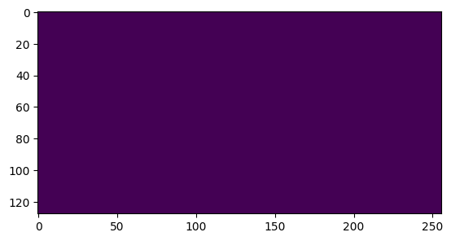

```python
z = 0
slice = sitk.GetArrayViewFromImage(image)[z, :, :]
plt.imshow(slice)
```